# MSiA 400 Lab Assignment 1

Due Oct 13 at 5pm

Please submit a report file that includes: a short answer, related code, printouts, etc. for each problem (where necessary). Push your answers to Github. All programming must be in R (or R Markdown).

## Problem 1

You will analyze data from a website with 8 pages (plus a 9th state, indicating that the user has left the website). Formulate a Markov chain for this website where each state $\{S_i\ |\ i=1,\cdots,9\}$ corresponds to a page. Each visitor starts at the home page (Page 1), then browses from page-to-page until he/she leaves the website. So, a sample path may be $S_1\to S_3\to S_5\to S_9$, corresponding to a visitor starting on the home page, moving to Page 3, then Page 5, then leaving the website.

Attached is the dataset `webtraffic.txt`, which records the paths of 1000 visitors (rows). The data has 81 columns labeled $t11,t12,\cdots,t19,t21,t22,\cdots,t99$, where $t_{ij}$ represents a transition from State $i$ to State $j$, for $i,j\in\{1,\cdots,9\}$. Each visitor has a 1 in column $t_{ij}$ if the visitor clicked from Page $i$ to Page $j$, and 0 elsewhere. For example, the aforementioned sample path would have 1’s in columns $t_{13}$, $t_{35}$, and $t_{59}$ and 0’s elsewhere.

### Problem 1a

Construct a 9 by 9 matrix `Traffic` that counts total traffic from State $i$ to State $j$, for $i,j\in\{1,\cdots,9\}$. Note that `Traffic` has 0’s in row 9 and column 1. Set `Traffic[9,1]=1000`. (This is equivalent to making each user return to the home page after they leave the website.) Display `Traffic`. `colSums()` adds all rows for each column.

```r
# read file
webtraffic <- read.table(here::here("webtraffic.txt"), header = TRUE)
head(webtraffic)
```

```
##   t11 t12 t13 t14 t15 t16 t17 t18 t19 t21 t22 t23 t24 t25 t26 t27 t28 t29 t31
## 1   0   1   0   0   0   0   0   0   0   0   0   1   1   0   0   0   0   0   0
## 2   0   0   1   0   0   0   0   0   0   0   0   0   0   0   0   0   0   0   0
## 3   0   0   1   0   0   0   0   0   0   0   0   0   0   0   0   0   0   0   0
## 4   0   0   1   0   0   0   0   0   0   0   0   0   0   0   0   0   0   0   0
## 5   0   1   0   0   0   0   0   0   0   0   0   1   0   0   0   0   0   0   0
## 6   0   0   1   0   0   0   0   0   0   0   0   0   0   0   0   0   0   0   0
##   t32 t33 t34 t35 t36 t37 t38 t39 t41 t42 t43 t44 t45 t46 t47 t48 t49 t51 t52
## 1   1   0   0   0   0   0   0   0   0   0   0   0   0   1   0   0   0   0   0
## 2   0   0   1   0   0   0   0   0   0   0   0   0   0   1   0   0   0   0   0
## 3   0   0   1   0   0   0   0   0   0   0   0   0   0   0   1   0   0   0   0
## 4   0   0   1   0   0   0   0   0   0   0   0   0   1   0   0   0   0   0   0
## 5   0   0   1   0   0   0   0   0   0   0   0   0   0   0   1   0   0   0   0
## 6   0   0   1   0   0   0   0   0   0   0   0   0   0   0   1   0   0   0   0
##   t53 t54 t55 t56 t57 t58 t59 t61 t62 t63 t64 t65 t66 t67 t68 t69 t71 t72 t73
```

[output cut: 20 more lines]

```r
# create Traffic matrix
Traffic <- matrix(colSums(webtraffic), nrow = 9, ncol = 9, byrow = TRUE)

# set Traffic(9, 1) as 1000
Traffic[9, 1] <- 1000

# display Traffic
Traffic
```

```
##       [,1] [,2] [,3] [,4] [,5] [,6] [,7] [,8] [,9]
##  [1,]    0  447  553    0    0    0    0    0    0
##  [2,]    0   23  230  321    0    0    0    0   63
##  [3,]    0  167   43  520    0    0    0    0   96
##  [4,]    0    0    0   44  158  312  247    0  124
##  [5,]    0    0    0    0   22   52   90  127  218
##  [6,]    0    0    0    0   67   21    0  294   97
##  [7,]    0    0    0    0    0   94    7  185   58
##  [8,]    0    0    0    0  262    0    0   30  344
##  [9,] 1000    0    0    0    0    0    0    0    0
```

### Problem 1b

Draw a directed graph where each node represents a state, and each arrow from State $i$ to State $j$ has positive (non-zero) traffic (i.e., `Traffic[i,j]>0`). This may be submitted as a TikZ graph (or using your graphing program of choice) or a picture of a hand-drawn graph (provided it is legible). Is the Markov chain irreducible? Is the Markov chain ergodic? Explain.

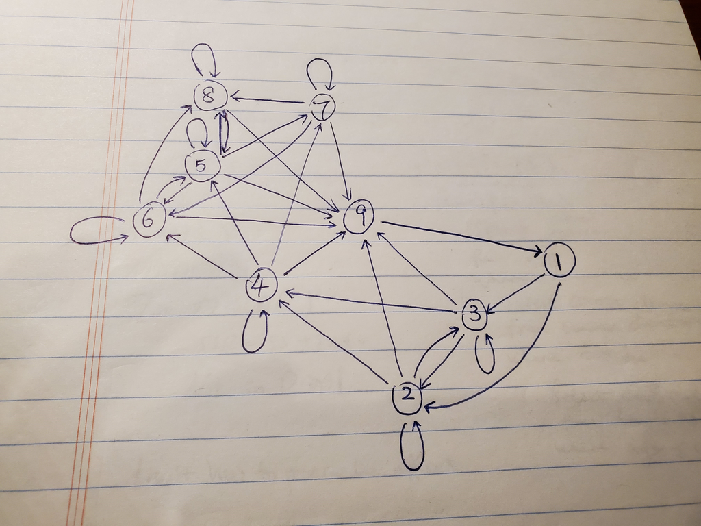

“markov_chain”

The Markov chain is irreducible, because you can get to every state (webpage) from any other state. More specifically, you can get to any state from state 1, and states 2-8 all point to 9. For any state i and j, if j = 1, then you can go from j to i. If j does not equal 1, then you can go from j to 9, 9 to 1, and 1 to i.